# Cruise Report: 2022-08-15 : 08-16

Recreational angling survey

Author

Mike O’Brien (UMCES)

## Participants

- Dave Secor (UMCES)
- Mike O’Brien (UMCES)
- Todd Sumner (US Wind, Inc.)
- Capt. Dan Stauffer (*F/V Fin Chaser*, captain)
- Joey M. (*F/V Fin Chaser*, mate)

## Description

|  | lon_dm | lat_dm | depth_m | wind_sp_kts | wind_dir_deg | wave_ht_m | wave_swell_m | cloud_cover_tnth |
| --- | --- | --- | --- | --- | --- | --- | --- | --- |
| washingtonian | 74 46.071 | 38 25.858 | 23.5 | 15-20 | 45 | 0.9-1.2 | 1.5 | 3 |
| K07 | 74 42.267 | 38 21.225 | 29.0 | 20-22 | 45 | 0.6-0.9 | 1.2 | 3 |

## Fish summary

Fish showed some outward signs of barotrauma, mostly the intestines protruding from the anus. All but one black sea bass was jaw-hooked (the least-damaging hook position). Fewer black sea bass ans substantially more searobins were caught as compared to the June cruise. As in the June cruise, all black sea bass were caught at the control wreck, and all searobins were caught at a future turbine site.

| Species catch species | Species catch n |
| --- | --- |
| June - N11 |  |
| n searobin | 4 |
| June - twin wrecks |  |
| bsb | 19 |
| cunner | 1 |
| August - K07 |  |
| longfin squid | 1 |
| n searobin | 26 |
| August - washingtonian |  |
| bsb | 8 |
| tautog | 1 |

Black sea bass catch is summarized below. Summaries are only provided for the wreck (control) sites, as no black sea bass were caught at turbine (experimental) sites.

| Black sea bass catch Wreck sites only | Black sea bass catch Wreck sites only Angler | Black sea bass catch Wreck sites only BSB | Black sea bass catch Wreck sites only Drops | Black sea bass catch Wreck sites only BSB/drop mean | Black sea bass catch Wreck sites only BSB/drop SD |
| --- | --- | --- | --- | --- | --- |
| June |  |  |  |  |  |
|  | DHS | 2 | 14 | 0.15 | 0.38 |
|  | JM | 7 | 15 | 0.47 | 0.52 |
|  | RJ | 5 | 15 | 0.36 | 0.50 |
| mean | — | 4.67 | — | 0.33 | 0.47 |
| sd | — | 2.52 | — | 0.16 | 0.08 |
| August |  |  |  |  |  |
|  | DHS | 1 | 15 | 0.13 | 0.35 |
|  | JM | 2 | 15 | 0.13 | 0.35 |
|  | TS | 2 | 15 | 0.21 | 0.43 |
| mean | — | 1.67 | — | 0.16 | 0.38 |
| sd | — | 0.58 | — | 0.05 | 0.05 |
| Grand mean | — | 3.17 | — | 0.24 | 0.42 |
| Grand SD | — | 2.32 | — | 0.14 | 0.07 |

Most black sea bass caught were under-sized; the red line shows fish of legal length (>320 mm).

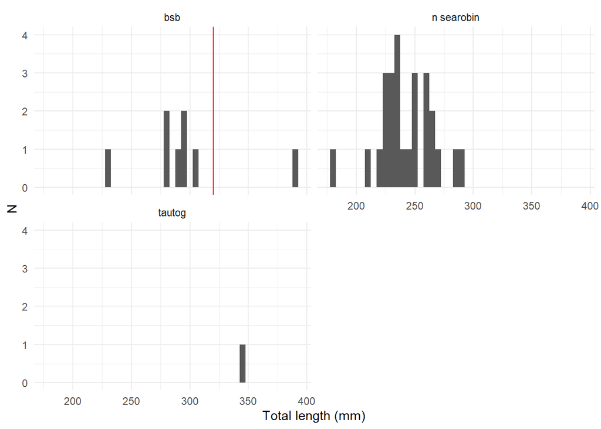

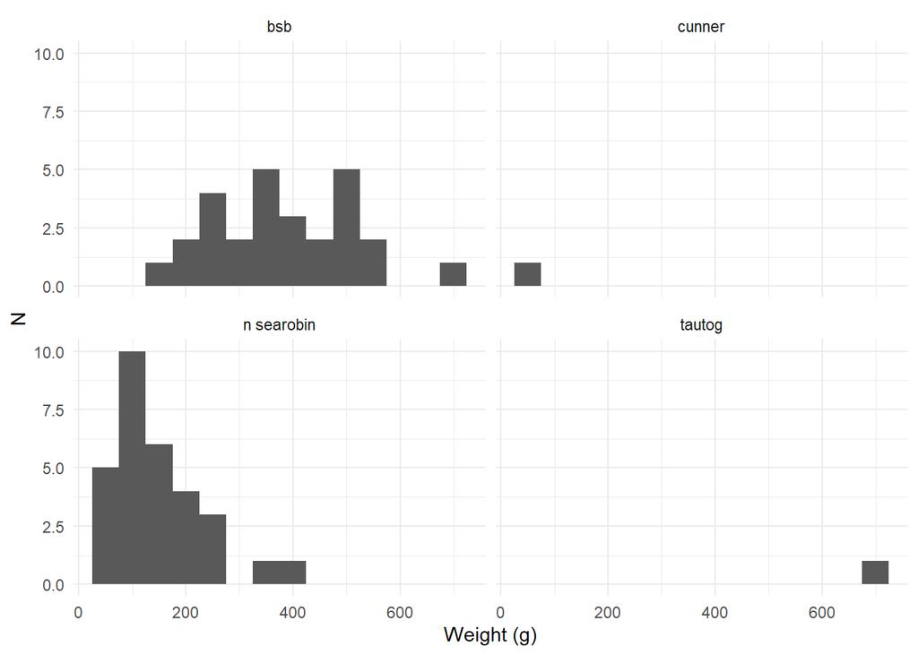

The effect of angler experience – namely *JM*, the *Fin Chaser* mate, was much less pronounced in August as compared to June. This may also reflect underlying differences in abundance or catchability at the two reef sites.

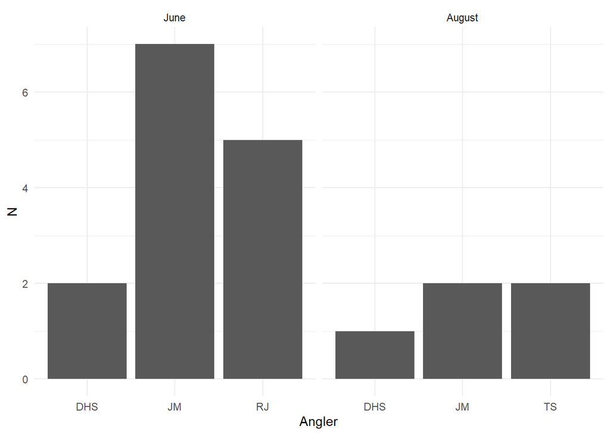

## Cruise map

[interactive chart not shown]